# QK Box 9.2

We fitted a model relating species richness of shallow water ostracods to seven environmental predictors: water depth, bottom water temperature, salinity, productivity (particulate organic carbon flux to ocean floor), productivity squared (because of commonly observed hump-shaped relationships between richness and productivity in marine systems), seasonal variation in productivity, and the annual number of ice-free days; n = 129). To be consistent with Yasuhara et al’s original analysis, water depth and seasonal variation in productivity were both positively skewed and were log-transformed, although the same argument could have been used for temperature. Additionally, all predictors were centered; note that centering does not affect the recommended measures of relative importance.

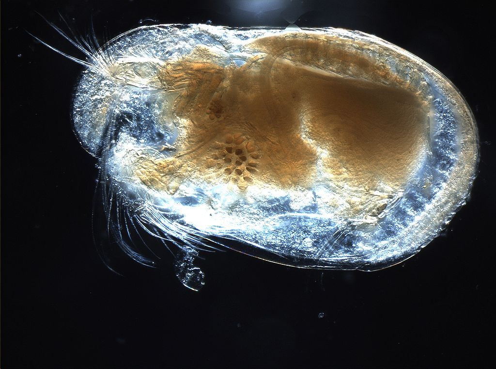

Ostracod. Anna Syme, [CC Attribution 2.5 Generic](https://creativecommons.org/licenses/by/2.5/deed.en)

The paper is [here](https://doi.org/10.1111/j.1365-2699.2012.02758.x)

Yasuhara, M., Hunt, G., van Dijken, G., Arrigo, K. R., Cronin, T. M. & Wollenburg, J. E. (2012). Patterns and controlling factors of species diversity in the Arctic Ocean. *Journal of Biogeography*, 39, 2081-88.

### Preliminaries

First, load the required packages (relaimpo, car, hier.part, MuMIn, lm.beta)

Import yasuhara data file (yasuhara.csv)

**Note.** The yasuhara file associated with the paper is the full data set. The analyses of shallow-water ostracods used a subset of that data. Four deep sites (depth >200m) were excluded, as were three with a freshwater influence (salinity <21)

```r
yasuhara <- read.csv("../data/yasuhara.csv")
yasuhara <- subset(yasuhara, salinity>21 & depth <= 200)
head(yasuhara,10)
```

|  | e100 | depth | rc | temp | salinity | seasprod | icefree | prod | lat | lon | sprich |
| --- | --- | --- | --- | --- | --- | --- | --- | --- | --- | --- | --- |
| 1 | 13.078359 | 26.0 | 2 | -0.8923 | 31.2973 | 2.407069 | 293.3 | 62.27090 | 70.30 | -146.08 | 14 |
| 2 | 11.503938 | 31.0 | 2 | -0.8991 | 31.3444 | 2.726143 | 307.3 | 46.83230 | 70.35 | -146.57 | 12 |
| 3 | 11.984957 | 27.0 | 2 | -0.7560 | 31.2805 | 4.244607 | 330.8 | 64.80130 | 70.22 | -148.07 | 14 |
| 4 | 14.644815 | 41.0 | 2 | -0.8733 | 31.9668 | 3.300005 | 322.4 | 18.04455 | 70.82 | -148.05 | 15 |
| 5 | 21.634426 | 24.0 | 2 | -1.2173 | 31.4632 | 2.924774 | 322.9 | 28.15754 | 70.73 | -148.80 | 23 |
| 6 | 7.794047 | 19.8 | 2 | -0.8745 | 30.7309 | 2.862883 | 313.6 | 46.24408 | 70.87 | -150.50 | 10 |
| 7 | 6.870187 | 39.0 | 2 | -0.9741 | 31.2562 | 2.395763 | 298.4 | 77.24982 | 70.14 | -145.48 | 7 |
| 8 | 12.419051 | 26.0 | 2 | -0.8991 | 31.3444 | 2.726143 | 307.3 | 46.83230 | 70.36 | -146.60 | 16 |
| 9 | 9.235467 | 19.0 | 2 | -0.8745 | 30.7309 | 3.274172 | 316.0 | 36.79187 | 70.99 | -150.53 | 10 |
| 10 | 7.617345 | 4.0 | 2 | -0.4913 | 28.2688 | 2.161363 | 291.2 | 106.35688 | 70.46 | -148.77 | 8 |

## First we repeat shallow-water ostracod analysis as in Table 1 of paper

**Note:** have changed original csv file names to match those in code below

### Scatterplot matrix

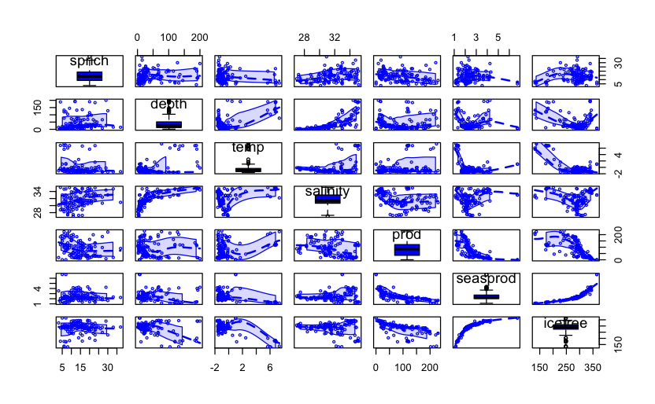

```r
scatterplotMatrix(~sprich+depth+temp+salinity+prod+seasprod+icefree, data=yasuhara, cex=.5, regLine=FALSE, diagonal=list(method='boxplot'))
```

Transform variables as needed, including quadratic for productivity

Center predictors as well

```r
yasuhara$prod2 <- (yasuhara$prod)^2
yasuhara$ldepth <- log10(yasuhara$depth)
yasuhara$lseasprod <- log10(yasuhara$seasprod)
yasuhara$cldepth <- scale(yasuhara$ldepth, center=TRUE, scale=FALSE)
yasuhara$ctemp <- scale(yasuhara$temp, center=TRUE, scale=FALSE)
yasuhara$csalinity <- scale(yasuhara$salinity, center=TRUE, scale=FALSE)
yasuhara$cprod <- scale(yasuhara$prod, center=TRUE, scale=FALSE)
yasuhara$cprod2 <- scale(yasuhara$prod2, center=TRUE, scale=FALSE)
yasuhara$clseasprod <- scale(yasuhara$lseasprod, center=TRUE, scale=FALSE)
yasuhara$cicefree <- scale(yasuhara$icefree, center=TRUE, scale=FALSE)
```

Get VIFs to check for collinearity issues; also look at correlations Fit regression model to get influence measures

```r
vif(lm(sprich~cldepth+ctemp+csalinity+cprod+cprod2+clseasprod+cicefree, data=yasuhara))
```

```
   cldepth      ctemp  csalinity      cprod     cprod2 clseasprod   cicefree
  4.352417   3.543887   4.992620  27.660590  20.767683  15.523035  20.760021
```

```r
cor(yasuhara[,c('cldepth','ctemp','csalinity','cprod','cprod2','clseasprod','cicefree')])
```

```
               cldepth      ctemp   csalinity       cprod      cprod2  clseasprod   cicefree
cldepth     1.00000000  0.3891785  0.84784714 -0.09488397  0.01871298 -0.08130645 -0.2781119
ctemp       0.38917848  1.0000000  0.34629660  0.22755053  0.22625504 -0.52110033 -0.7319989
csalinity   0.84784714  0.3462966  1.00000000 -0.32989442 -0.22711552  0.05660052 -0.1560640
cprod      -0.09488397  0.2275505 -0.32989442  1.00000000  0.95956750 -0.72386615 -0.6336593
cprod2      0.01871298  0.2262550 -0.22711552  0.95956750  1.00000000 -0.63201614 -0.5939684
clseasprod -0.08130645 -0.5211003  0.05660052 -0.72386615 -0.63201614  1.00000000  0.9210498
cicefree   -0.27811191 -0.7319989 -0.15606404 -0.63365926 -0.59396839  0.92104981  1.0000000
```

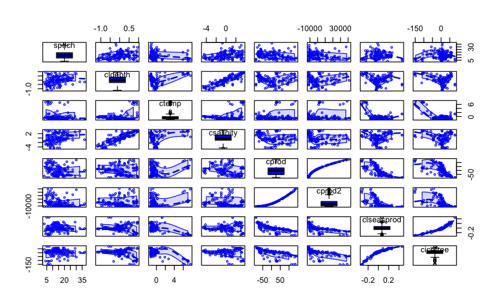

```r
scatterplotMatrix(~sprich+cldepth+ctemp+csalinity+cprod+cprod2+clseasprod+cicefree, data=yasuhara, cex=.5, regLine=FALSE, diagonal=list(method='boxplot'))
```